# Modelagem

Carolina Felix, Eduardo Aguirra e João Claudio Miranda

2024-09-22

## Métricas de Desempenho

Em nosso contexto, onde o objetivo é prever se uma empresa vai deixar de operar ,porém a proporção desse evento é muito baixa, a acurácia não é a métrica ideal. Como aproximadamente 97% das empresas não deixam de operar, se o modelo classificar todas as observações como empresas operando, ele terá uma acúrácia de 97%. Vamos usar a AUC para escolher o modelo e avaliar a qualidade do modelo usando usando a métrica F1-Score.

## Contexto financeiro: Função de Lucro esperado

Se tivermos lucros e prejuízos associados com previsões corretas e erradas, podemos escolher um modelo e um ponto de corte que maximiza o lucro esperado.

### Matriz de retornos

$$\begin{array}{|c|c|c|}
\hline
& \text{Previsto: Sim} & \text{Previsto: Não} \\
\hline
\text{Observado: Sim} & Lucro_{TP} & prejuizo_{FN} \\
\hline
\text{Observado: Não} & prejuizo_{FP} & Lucro_{TN} \\
\hline
\end{array}$$

- $Lucro_{TP}$ é o lucro associado a um verdadeiro positivo.
- $Lucro_{TN}$ é o lucro associado a um verdadeiro negativo.
- $prejuizo_{FP}$ é o prejuízo causado por um falso positivo.
- $prejuizo_{FN}$ é o prejuízo causado por um falso negativo.

### Matriz de confusão

$$\begin{array}{|c|c|c|}
\hline
& \text{Previsto: Sim} & \text{Previsto: Não} \\
\hline
\text{Observado: Sim} & TP & FN \\
\hline
\text{Observado: Não} & FP & TN \\
\hline
\end{array}$$

A função de lucro esperado pode ser definida da seguinte maneira:

$$Lucro esperado = \frac{1}{n}[(TP \times Lucro_{TP}) + (TN \times
Lucro_{TN}) + (FP \times prejuizo_{FP}) + (FN \times prejuizo_{FN})]$$

Com essa função,podemos escolher o modelo e o ponto de corte que maximiza nosso lucro esperado

## Modelos

### Carregando pacotes

```r
library(tidyverse)
library(modeldata)
library(glmnet)
library(ranger)
library(rpart)
library(rsample)
library(vip)
library(pROC)
library(yardstick)
library(PRROC)
library(MLmetrics)
library(vip)
library(ROSE)
library(skimr)
library(MLmetrics)
```

### Carregando o banco de dados

```r
dados <- read.csv("C:/Users/joaoclaudio/Documents/Pads/Estat 1/dados_v3_R.csv")
```

proporção da variável resposta

```r
prop.table(table(dados$Deixou.de.operar))
```

```
##
##          0          1
## 0.96544894 0.03455106
```

Como vimos na preparação dos dados, a proporção de empresas que deixaram de operar é muito baixa. Logo, além de testar os modelos nos dados completos, vamos usar técnicas de under e oversampling para gerar novos bancos de dados para treinar os modelos, e o teste será feito no conjunto previamente separado

#### Verificando se os dados foram importados corretamente e se o tipo das variáveis estão corretos

```r
dados %>%
 skim()
```

Data summary

| Name | Piped data |
| --- | --- |
| Number of rows | 18176 |
| Number of columns | 49 |
| _______________________ |  |
| Column type frequency: |  |
| character | 4 |
| numeric | 45 |
| ________________________ |  |
| Group variables | None |

**Variable type: character**

| skim_variable | n_missing | complete_rate | min | max | empty | n_unique | whitespace |
| --- | --- | --- | --- | --- | --- | --- | --- |
| gender | 0 | 1 | 3 | 6 | 0 | 3 | 0 |
| origin | 0 | 1 | 3 | 8 | 0 | 3 | 0 |
| ind | 0 | 1 | 3 | 14 | 0 | 4 | 0 |
| region_m | 0 | 1 | 0 | 7 | 50 | 4 | 0 |

**Variable type: numeric**

| skim_variable | n_missing | complete_rate | mean | sd | p0 | p25 | p50 | p75 | p100 | hist |
| --- | --- | --- | --- | --- | --- | --- | --- | --- | --- | --- |
| amort | 0 | 1 | 9822.52 | 50819.10 | 0.00 | 155.56 | 1018.52 | 4526.85 | 3570863.00 | ▇▁▁▁▁ |
| curr_assets | 0 | 1 | 105979.14 | 452348.47 | 0.00 | 3687.96 | 12496.30 | 43454.63 | 18745270.00 | ▇▁▁▁▁ |
| curr_liab | 0 | 1 | 89028.55 | 430768.48 | 0.00 | 3762.04 | 14877.78 | 49353.70 | 36601180.00 | ▇▁▁▁▁ |
| extra_exp | 0 | 1 | 442.99 | 7383.40 | 0.00 | 0.00 | 0.00 | 0.00 | 666300.00 | ▇▁▁▁▁ |
| extra_inc | 0 | 1 | 1727.87 | 33756.97 | 0.00 | 0.00 | 0.00 | 0.00 | 3266666.75 | ▇▁▁▁▁ |
| extra_profit_loss | 0 | 1 | 1281.43 | 33063.93 | -288888.88 | 0.00 | 0.00 | 0.00 | 3253703.75 | ▇▁▁▁▁ |
| fixed_assets | 0 | 1 | 154628.50 | 1136305.95 | 0.00 | 266.67 | 5548.15 | 45659.26 | 103667280.00 | ▇▁▁▁▁ |
| inc_bef_tax | 0 | 1 | 7622.56 | 133044.41 | -10918793.00 | -5767.59 | 366.67 | 4631.48 | 4378226.00 | ▁▁▁▇▁ |
| intang_assets | 0 | 1 | 3648.58 | 54999.35 | 0.00 | 0.00 | 0.00 | 0.00 | 3409751.75 | ▇▁▁▁▁ |
| inventories | 0 | 1 | 27386.28 | 210077.80 | 0.00 | 0.00 | 1296.30 | 7748.15 | 17258574.00 | ▇▁▁▁▁ |
| liq_assets | 0 | 1 | 26379.69 | 155604.40 | 0.00 | 503.70 | 2214.81 | 9974.07 | 7687870.50 | ▇▁▁▁▁ |
| material_exp | 0 | 1 | 175819.34 | 575820.43 | 0.00 | 10699.07 | 34781.48 | 105027.78 | 14127548.00 | ▇▁▁▁▁ |
| personnel_exp | 0 | 1 | 56648.69 | 219104.42 | 0.00 | 4403.70 | 11922.22 | 32244.45 | 7945803.50 | ▇▁▁▁▁ |
| profit_loss_year | 0 | 1 | 1767.07 | 116805.45 | -10918793.00 | -5789.81 | 133.33 | 2966.67 | 3926318.50 | ▁▁▁▇▁ |
| sales | 0 | 1 | 248992.54 | 796824.57 | 0.00 | 16110.19 | 47046.30 | 144567.60 | 9989311.00 | ▇▁▁▁▁ |
| share_eq | 0 | 1 | 101272.53 | 582337.93 | -10798185.00 | -6497.22 | 5057.41 | 35074.07 | 27175792.00 | ▁▇▁▁▁ |
| subscribed_cap | 0 | 1 | 31921.11 | 267299.16 | 0.00 | 1851.85 | 2592.59 | 11111.11 | 16319630.00 | ▇▁▁▁▁ |
| tang_assets | 0 | 1 | 141819.91 | 1088216.67 | 0.00 | 196.30 | 4968.52 | 41660.18 | 103665200.00 | ▇▁▁▁▁ |
| ceo_count | 0 | 1 | 1.29 | 0.55 | 1.00 | 1.00 | 1.00 | 2.00 | 15.00 | ▇▁▁▁▁ |
| foreign | 0 | 1 | 0.09 | 0.28 | 0.00 | 0.00 | 0.00 | 0.00 | 1.00 | ▇▁▁▁▁ |
| female | 0 | 1 | 0.26 | 0.40 | 0.00 | 0.00 | 0.00 | 0.50 | 1.00 | ▇▁▁▁▂ |
| inoffice_days | 0 | 1 | 3107.72 | 1715.40 | 10.00 | 1930.00 | 2677.00 | 3713.00 | 10041.00 | ▅▇▂▁▁ |
| urban_m | 0 | 1 | 2.08 | 0.84 | 1.00 | 1.00 | 2.00 | 3.00 | 3.00 | ▆▁▆▁▇ |
| company_age | 0 | 1 | 9.03 | 6.94 | 0.00 | 3.00 | 8.00 | 15.00 | 34.00 | ▇▅▅▁▁ |
| revenue | 0 | 1 | 250720.40 | 800346.81 | 1000.00 | 16340.74 | 47479.63 | 145679.63 | 9989311.00 | ▇▁▁▁▁ |
| Deixou.de.operar | 0 | 1 | 0.03 | 0.18 | 0.00 | 0.00 | 0.00 | 0.00 | 1.00 | ▇▁▁▁▁ |
| asinh_profit_loss_year | 0 | 1 | 0.43 | 9.01 | -16.90 | -9.36 | 5.59 | 8.69 | 15.88 | ▃▇▁▇▅ |
| asinh_inc_bef_tax | 0 | 1 | 0.94 | 9.30 | -16.90 | -9.35 | 6.60 | 9.13 | 15.99 | ▃▇▁▇▅ |
| asinh_share_eq | 0 | 1 | 3.45 | 10.09 | -16.89 | -9.47 | 9.22 | 11.16 | 17.81 | ▅▃▁▇▆ |
| asinh_extra_profit_loss | 0 | 1 | 0.22 | 2.96 | -13.27 | 0.00 | 0.00 | 0.00 | 15.69 | ▁▁▇▁▁ |
| log_liq_assets | 0 | 1 | 7.65 | 2.38 | 0.00 | 6.22 | 7.70 | 9.21 | 15.86 | ▁▃▇▃▁ |
| log_curr_liab | 0 | 1 | 9.39 | 2.34 | 0.00 | 8.23 | 9.61 | 10.81 | 17.42 | ▁▁▇▅▁ |
| log_amort | 0 | 1 | 6.19 | 3.30 | 0.00 | 5.05 | 6.93 | 8.42 | 15.09 | ▃▃▇▂▁ |
| log_extra_exp | 0 | 1 | 0.48 | 1.75 | 0.00 | 0.00 | 0.00 | 0.00 | 13.41 | ▇▁▁▁▁ |
| log_personnel_exp | 0 | 1 | 8.72 | 3.14 | 0.00 | 8.39 | 9.39 | 10.38 | 15.89 | ▂▁▇▇▁ |
| log_curr_assets | 0 | 1 | 9.47 | 2.05 | 0.00 | 8.21 | 9.43 | 10.68 | 16.75 | ▁▁▇▅▁ |
| log_material_exp | 0 | 1 | 10.38 | 1.94 | 0.00 | 9.28 | 10.46 | 11.56 | 16.46 | ▁▁▅▇▁ |
| log_extra_inc | 0 | 1 | 0.65 | 2.24 | 0.00 | 0.00 | 0.00 | 0.00 | 15.00 | ▇▁▁▁▁ |
| log_intang_assets | 0 | 1 | 1.12 | 2.75 | 0.00 | 0.00 | 0.00 | 0.00 | 15.04 | ▇▁▁▁▁ |
| log_fixed_assets | 0 | 1 | 7.46 | 4.47 | 0.00 | 5.59 | 8.62 | 10.73 | 18.46 | ▅▃▇▃▁ |
| log_inventories | 0 | 1 | 5.54 | 4.32 | 0.00 | 0.00 | 7.17 | 8.96 | 16.66 | ▆▂▇▂▁ |
| log_revenue | 0 | 1 | 10.83 | 1.71 | 6.91 | 9.70 | 10.77 | 11.89 | 16.12 | ▂▇▇▃▁ |
| log_tang_assets | 0 | 1 | 7.33 | 4.49 | 0.00 | 5.28 | 8.51 | 10.64 | 18.46 | ▅▃▇▃▁ |
| log_subscribed_cap | 0 | 1 | 8.21 | 1.91 | 0.00 | 7.52 | 7.86 | 9.32 | 16.61 | ▁▂▇▁▁ |
| log_sales | 0 | 1 | 10.80 | 1.78 | 0.00 | 9.69 | 10.76 | 11.88 | 16.12 | ▁▁▃▇▂ |

## Separando dados de treino e teste

Vamos usar o padrão de separar em 70% treino e 30% teste, extratificando pela variável resposta

```r
library(rsample)
set.seed(123)
splits <- initial_split(dados, prop = .7, strata = Deixou.de.operar)
treino <- training(splits)
teste <- testing(splits)
```

### Regressão logística

```r
logistica <- glm(Deixou.de.operar ~ ., data = treino,
           family = "binomial")
y_logistica <- predict(logistica, teste, type = "response")
```

### Lasso

```r
#ajustando a matriz modelo de treinamento
X_tr <- model.matrix(Deixou.de.operar ~ ., treino)[,-1]
y_tr <- treino$Deixou.de.operar

#ajustando a matriz modelo de teste
X_test <- model.matrix(Deixou.de.operar ~ ., teste)[,-1]
y_test <- teste$Deixou.de.operar

#modelo
lasso <- glmnet(X_tr, y_tr,
                family = "binomial",
                alpha = 1,
                nlambda = 500)

# otimizando o lambda atrés da validação cruzada
cv_lasso <- cv.glmnet(X_tr, y_tr, alpha = 1, lambda = lasso$lambda)

#vetor de probabilidades preditas
y_lasso <- predict(lasso, newx = X_test,
                   s = cv_lasso$lambda.1se,type = "response")
```

### Ridge

```r
#modelo
ridge <- glmnet(X_tr, y_tr,
                family = "binomial",
                alpha = 0,
                nlambda = 500)

# otimizando o lambda atrés da validação cruzada
cv_ridge <- cv.glmnet(X_tr, y_tr, alpha = 0, lambda = ridge$lambda)

#vetor de probabilidades preditas
y_ridge <- predict(ridge, newx = X_test,
                   s = cv_ridge$lambda.1se,type = "response")
```

### Elastic_net

```r
#modelo
elastic_net <- glmnet(X_tr,y_tr,
                      family = "binomial",
                      alpha = 0.5,
                      nlambda = 500)

# otimizando o lambda atrés da validação cruzada
cv_elastic_net <- cv.glmnet(X_tr, y_tr, alpha = 0.5, lambda = elastic_net$lambda)

#vetor de probabilidades preditas
y_elastic_net <- predict(elastic_net, newx = X_test,
                         s=cv_elastic_net$lambda.1se,type = "response")
```

### Floresta aleatória

```r
set.seed(123)

# Vamos retirar aquelas variáveis originais que foram trasnformadas, e ficar somente com as transformadas.

nomes_var_originais <- treino %>%
  select(c(starts_with("log"),starts_with("asinh"))) %>%
  names() %>%
  str_remove("log_") %>% str_remove("asinh_")

treino_floresta <- treino %>%
  select(-all_of(nomes_var_originais))


#Vamos criar uma lista de combinações entre números de variáveis e número de arvores
hiper_parametros <- crossing(mtry = c(10,15,25),
                             n_arvores = c(150,300,750))

# função que ajusta uma árvore para uma dada combinação de hiperparâmetros
ajusta_arvore <- function(mtry, n_arvores) {
  rf <- ranger(Deixou.de.operar ~ .,
               num.trees = n_arvores,
               mtry = mtry, data = treino_floresta)
  return(rf$prediction.error)
}

hiper_parametros <- hiper_parametros %>%
  mutate(erro = map2_dbl(mtry, n_arvores, ajusta_arvore)) %>%
  arrange(erro)

#Utilizando os hiper parâmetros otimizados
rf_original <- ranger(Deixou.de.operar ~ .,
             probability = TRUE,
             num.trees = hiper_parametros$n_arvores[1],
             mtry = hiper_parametros$mtry[1],
             importance = "permutation",
             data = treino_floresta)

y_floresta <- predict(rf_original, teste)$predictions[,2]
```

### Métricas de avaliação

criando um data frame com as probabilidades preditas e os valores observados

```r
df_avaliacao <- tibble(probabilidade = y_logistica,
                       deixou_operar = as.factor(teste$Deixou.de.operar),
                    modelo = "Logística") %>%
  bind_rows(tibble(probabilidade = y_lasso,
                     deixou_operar = as.factor(teste$Deixou.de.operar),
                    modelo = "lasso")) %>%
  bind_rows(tibble(probabilidade = y_ridge,
                     deixou_operar = as.factor(teste$Deixou.de.operar),
                    modelo = "Ridge")) %>%
   bind_rows(tibble(probabilidade = y_elastic_net,
                     deixou_operar = as.factor(teste$Deixou.de.operar),
                    modelo = "elastic")) %>%
  bind_rows(tibble(probabilidade = y_floresta,
                     deixou_operar = as.factor(teste$Deixou.de.operar),
                   modelo = "floresta"))
```

### Curva ROC

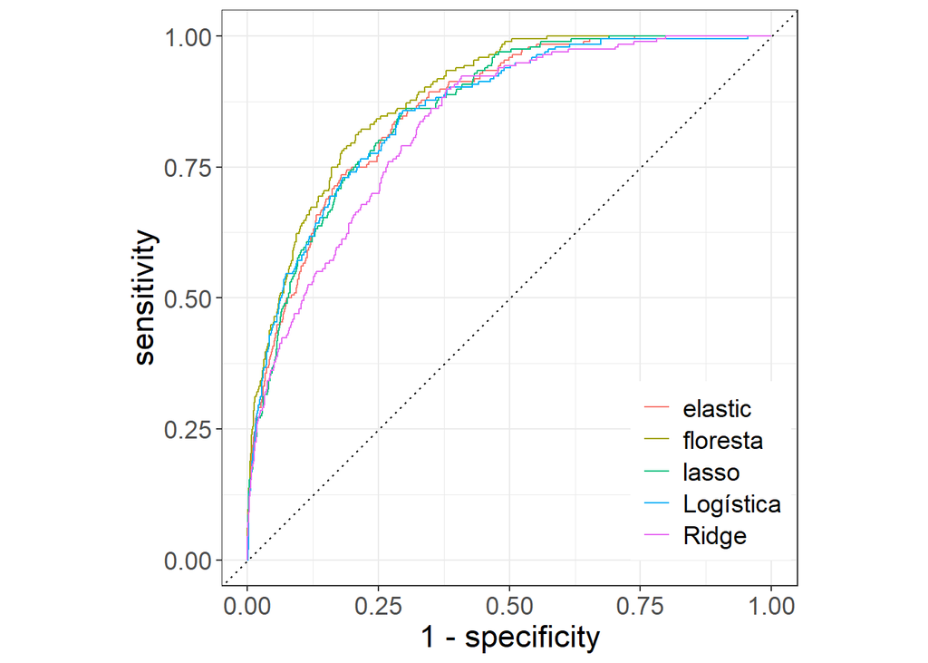

```r
df_avaliacao %>%
  mutate(probabilidade=as.numeric(probabilidade)) %>%
    group_by(modelo) %>%
    roc_curve(deixou_operar, probabilidade,event_level = "second") %>%
    autoplot() +
    labs(color = NULL) +
    theme(legend.position = c(.85, .2),
    text = element_text(size = 17))
```

Pelo gráfico da curva ROC, podemos notar um desempenho melhor da floresta aleatória

# AUC

```r
roc_logistica <- roc(teste$Deixou.de.operar, y_logistica)
roc_lasso <-roc(teste$Deixou.de.operar,y_lasso)
roc_ridge <-roc(teste$Deixou.de.operar,y_ridge)
roc_elastic <-roc(teste$Deixou.de.operar,y_elastic_net)
roc_floresta <-roc(teste$Deixou.de.operar,y_floresta)

# Extrair os valores de AUC
auc_logistica <- auc(roc_logistica)
auc_lasso <- auc(roc_lasso)
auc_ridge <- auc(roc_ridge)
auc_elastic <- auc(roc_elastic)
auc_floresta <- auc(roc_floresta)

auc_table <- tibble(
  Modelo = c("logistica","lasso", "ridge", "elastic","floresta"),
  dataset = "original",
  AUC = c(auc_logistica, auc_lasso, auc_ridge,auc_elastic,auc_floresta)
) %>%
  arrange(desc(AUC))


# Exibir a tabela
print(auc_table)
```

```
## # A tibble: 5 × 3
##   Modelo    dataset    AUC
##   <chr>     <chr>    <dbl>
## 1 floresta  original 0.885
## 2 elastic   original 0.863
## 3 lasso     original 0.862
## 4 logistica original 0.860
## 5 ridge     original 0.833
```

Para esse dataset, a floresta aleatória tem o melhor desempenho, elastic,lasso e logística tem desempenho semelhante, e a ridge,pior que as demais.

### F1-SCORE

Vamos criar uma função para calcular o F1-Score para um dado modelo e um dado ponto de corte

```r
ajusta_f1 <- function(corte,modelo) {
  y_predito= case_when(modelo=="logistica"~ y_logistica,
                       modelo=="lasso"    ~ y_lasso,
                       modelo=="ridge"    ~ y_ridge,
                       modelo=="elastic"   ~ y_elastic_net,
                       modelo=="floresta" ~ y_floresta)

  y_corte = ifelse(y_predito>corte,1,0)

  f1=F1_Score(y_pred = y_corte, y_true = teste$Deixou.de.operar,positive = 1)

  return(f1)
}
```

criando a tabela de resultados

```r
f1_score <- crossing(modelo = c("logistica","lasso",
                                        "ridge","elastic","floresta"),
                             corte=seq(0, 1, 0.001))

f1_score <- f1_score %>%
  mutate(dataset="original",
    f1 = map2_dbl(corte, modelo, ajusta_f1)) %>%
  arrange(desc(f1))

f1_score
```

| modelo | corte | dataset | f1 |
| --- | --- | --- | --- |
| floresta | 0.291 | original | 0.367469880 |
| floresta | 0.306 | original | 0.365930599 |
| floresta | 0.307 | original | 0.365930599 |
| floresta | 0.308 | original | 0.365930599 |
| floresta | 0.309 | original | 0.365930599 |
| floresta | 0.310 | original | 0.365930599 |
| floresta | 0.299 | original | 0.365325077 |
| floresta | 0.300 | original | 0.365325077 |
| floresta | 0.288 | original | 0.365269461 |
| floresta | 0.289 | original | 0.365269461 |

[output cut: 4995 more lines]

Nota-se, que o desempenho dos modelos é bem pobre em relação a essa métrica. Não conseguimos um balanceamento satisfatório entre sensibilidade e precisão

## Balanceamento entre as classes.

Vamos testar primeiro o undersample, reduzindo observações das empresas que não deixaram de operar.Testamos vários tamanhos de redução, e o melhor que observamos foi uma proporção de 3:1.

```r
under_treino <- ovun.sample(Deixou.de.operar ~ ., data = treino,
                            method = "under",
                            N =sum(treino$Deixou.de.operar==1)*4,
                          seed = 123)$data
table(under_treino$Deixou.de.operar)
```

```
##
##    0    1
## 1296  432
```

```r
prop.table(table(under_treino$Deixou.de.operar))
```

```
##
##    0    1
## 0.75 0.25
```

### Regressão logística

```r
logistica <- glm(Deixou.de.operar ~ ., data = under_treino,
           family = "binomial")
y_logistica <- predict(logistica, teste, type = "response")
```

### Lasso

```r
#ajustando a matriz modelo de treinamento
X_tr <- model.matrix(Deixou.de.operar ~ ., under_treino)[,-1]
y_tr <- under_treino$Deixou.de.operar

#ajustando a matriz modelo de teste
X_test <- model.matrix(Deixou.de.operar ~ ., teste)[,-1]
y_test <- teste$Deixou.de.operar

#modelo
lasso <- glmnet(X_tr, y_tr,
                family = "binomial",
                alpha = 1,
                nlambda = 400)

# otimizando o lambda atrés da validação cruzada
cv_lasso <- cv.glmnet(X_tr, y_tr, alpha = 1, lambda = lasso$lambda)

#vetor de probabilidades preditas
y_lasso <- predict(lasso, newx = X_test,
                   s = cv_lasso$lambda.1se,type = "response")
```

### Ridge

```r
#modelo
ridge <- glmnet(X_tr, y_tr,
                family = "binomial",
                alpha = 0,
                nlambda = 400)

# otimizando o lambda atrés da validação cruzada
cv_ridge <- cv.glmnet(X_tr, y_tr, alpha = 0, lambda = ridge$lambda)

#vetor de probabilidades preditas
y_ridge <- predict(ridge, newx = X_test,
                   s = cv_ridge$lambda.1se,type = "response")
```

### Elastic_net

```r
#modelo
elastic_net <- glmnet(X_tr,y_tr,
                      family = "binomial",
                      alpha = 0.5,
                      nlambda = 400)

# otimizando o lambda atrés da validação cruzada
cv_elastic_net <- cv.glmnet(X_tr, y_tr, alpha = 0.5, lambda = elastic_net$lambda)

#vetor de probabilidades preditas
y_elastic_net <- predict(elastic_net, newx = X_test,
                         s=cv_elastic_net$lambda.1se,type = "response")
```

### Floresta aleatória

```r
set.seed(123)

#selecionando variáveis
treino_floresta <- under_treino %>%
  select(-all_of(nomes_var_originais))

#Vamos criar uma lista de combinações entre números de variáveis e número de arvores

hiper_parametros <- crossing(mtry = c(10,15,25),
                      n_arvores =c(150,300,750))
# função que ajusta uma árvore para uma dada combinação de hiperparâmetros
ajusta_arvore <- function(mtry, n_arvores) {
  rf <- ranger(Deixou.de.operar ~ .,
               num.trees = n_arvores,
               mtry = mtry, data = treino_floresta)
  return(rf$prediction.error)
}

hiper_parametros <- hiper_parametros %>%
  mutate(erro = map2_dbl(mtry, n_arvores, ajusta_arvore)) %>%
  arrange(erro)

#Utilizando os hiper parâmetros otimizados
rf_under <- ranger(Deixou.de.operar ~ .,
             probability = TRUE,
             num.trees = hiper_parametros$n_arvores[1],
             mtry = hiper_parametros$mtry[1],
             importance = "permutation",
             data = treino_floresta)

y_floresta <- predict(rf_under, teste)$predictions[,2]
```

### Métricas de avaliação

criando um data frame com as probabilidades preditas e os valores observados

```r
df_avaliacao <- tibble(probabilidade = y_logistica,
                       deixou_operar = as.factor(teste$Deixou.de.operar),
                    modelo = "Logística") %>%
  bind_rows(tibble(probabilidade = y_lasso,
                     deixou_operar = as.factor(teste$Deixou.de.operar),
                    modelo = "lasso")) %>%
  bind_rows(tibble(probabilidade = y_ridge,
                     deixou_operar = as.factor(teste$Deixou.de.operar),
                    modelo = "Ridge")) %>%
   bind_rows(tibble(probabilidade = y_elastic_net,
                     deixou_operar = as.factor(teste$Deixou.de.operar),
                    modelo = "elastic")) %>%
  bind_rows(tibble(probabilidade = y_floresta,
                     deixou_operar = as.factor(teste$Deixou.de.operar),
                   modelo = "floresta"))
```

### Curva ROC

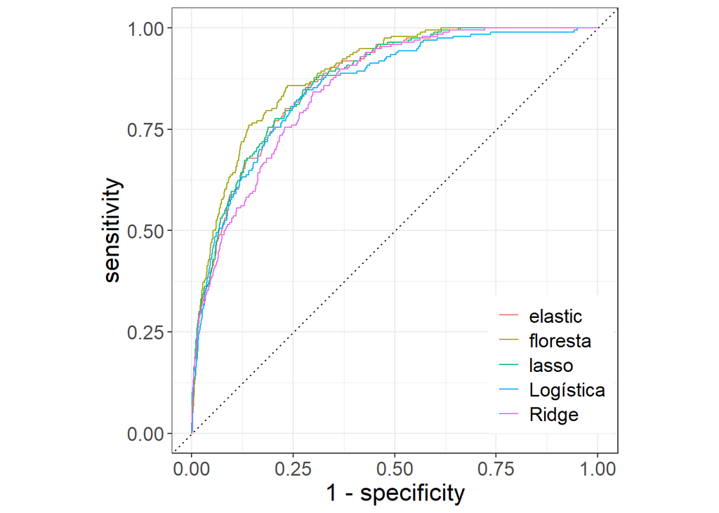

```r
df_avaliacao %>%
  mutate(probabilidade=as.numeric(probabilidade)) %>%
    group_by(modelo) %>%
    roc_curve(deixou_operar, probabilidade,event_level = "second") %>%
    autoplot() +
    labs(color = NULL) +
    theme(legend.position = c(.85, .2),
    text = element_text(size = 17))
```

A floresta se destaca neste gráfico também

### AUC

```r
roc_logistica <- roc(teste$Deixou.de.operar, y_logistica)
roc_lasso <-roc(teste$Deixou.de.operar,y_lasso)
roc_ridge <-roc(teste$Deixou.de.operar,y_ridge)
roc_elastic <-roc(teste$Deixou.de.operar,y_elastic_net)
roc_floresta <-roc(teste$Deixou.de.operar,y_floresta)

# Extrair os valores de AUC
auc_logistica <- auc(roc_logistica)
auc_lasso <- auc(roc_lasso)
auc_ridge <- auc(roc_ridge)
auc_elastic <- auc(roc_elastic)
auc_floresta <- auc(roc_floresta)

auc_table <- auc_table %>%
  bind_rows(tibble(
  Modelo = c("logistica","lasso", "ridge", "elastic","floresta"),
  dataset = "undersamplig",
  AUC = c(auc_logistica, auc_lasso, auc_ridge,auc_elastic,auc_floresta)
)) %>%
  arrange(desc(AUC))


# Exibir a tabela
print(auc_table)
```

```
## # A tibble: 10 × 3
##    Modelo    dataset        AUC
##    <chr>     <chr>        <dbl>
##  1 floresta  undersamplig 0.888
##  2 floresta  original     0.885
##  3 lasso     undersamplig 0.871
##  4 elastic   undersamplig 0.870
##  5 elastic   original     0.863
##  6 lasso     original     0.862
##  7 logistica original     0.860
##  8 logistica undersamplig 0.856
##  9 ridge     undersamplig 0.852
## 10 ridge     original     0.833
```

Com esse dataset o AUC da floresta aleatória melhorou marginalmente.

## F1-Score

```r
f1_score_under <- crossing(modelo = c("logistica","lasso",
                                        "ridge","elastic","floresta"),
                             corte=seq(0, 1, 0.001))

f1_score_under <- f1_score_under %>%
  mutate(dataset="undersamplig",
    f1 = map2_dbl(corte, modelo, ajusta_f1))

# juntando com os resultados do dataset original
f1_score <- bind_rows(f1_score,f1_score_under) %>%
  arrange(desc(f1))

f1_score
```

| modelo | corte | dataset | f1 |
| --- | --- | --- | --- |
| floresta | 0.291 | original | 0.367469880 |
| floresta | 0.306 | original | 0.365930599 |
| floresta | 0.307 | original | 0.365930599 |
| floresta | 0.308 | original | 0.365930599 |
| floresta | 0.309 | original | 0.365930599 |
| floresta | 0.310 | original | 0.365930599 |
| floresta | 0.299 | original | 0.365325077 |
| floresta | 0.300 | original | 0.365325077 |
| floresta | 0.288 | original | 0.365269461 |
| floresta | 0.289 | original | 0.365269461 |

[output cut: 9990 more lines]

Não tivemos melhora na F1-Score

### oversampling

Vamos testar a precisão dos modelos gerando observações artificiais das empresas que deixaram de operar. Vamos aumentar em 100% a quantidade dessas empresas. Para isso, vamos usar a função ROSE

```r
#ajustando os dados para o pacote
treino_rose= treino %>%
  mutate(region_m= as.factor(region_m),
         gender=as.factor(gender),
         origin=as.factor(origin),
         ind=as.factor(ind))


# Criar os dados
treino_rose <- ROSE(Deixou.de.operar~.,data=treino_rose,p=0.07,seed=123)$data


# Verificar a distribuição das classes após a geração dos dados sintéticos
table(treino_rose$Deixou.de.operar)
```

```
##
##     0     1
## 11861   862
```

```r
prop.table(table(treino_rose$Deixou.de.operar))
```

```
##
##          0          1
## 0.93224868 0.06775132
```

#### Regressão logística

```r
logistica <- glm(Deixou.de.operar ~ ., data = treino_rose,
           family = "binomial")
y_logistica <- predict(logistica, teste, type = "response")
```

#### lasso

```r
#ajustando a matriz modelo de treinamento
X_tr <- model.matrix(Deixou.de.operar ~ ., treino_rose)[,-1]
y_tr <- treino_rose$Deixou.de.operar

#ajustando a matriz modelo de teste
X_test <- model.matrix(Deixou.de.operar ~ ., teste)[,-1]
y_test <- teste$Deixou.de.operar

#modelo
lasso <- glmnet(X_tr, y_tr,
                family = "binomial",
                alpha = 1,
                nlambda = 400)

# otimizando o lambda atrés da validação cruzada
cv_lasso <- cv.glmnet(X_tr, y_tr, alpha = 1, lambda = lasso$lambda)

#vetor de probabilidades preditas
y_lasso <- predict(lasso, newx = X_test,
                   s = cv_lasso$lambda.1se,type = "response")
```

#### Ridge

```r
#ajustando a matriz modelo de treinamento
X_tr <- model.matrix(Deixou.de.operar ~ ., treino_rose)[,-1]
y_tr <- treino_rose$Deixou.de.operar

#ajustando a matriz modelo de teste
X_test <- model.matrix(Deixou.de.operar ~ ., teste)[,-1]
y_test <- teste$Deixou.de.operar

#modelo
ridge <- glmnet(X_tr, y_tr,
                family = "binomial",
                alpha = 0,
                nlambda = 400)

# otimizando o lambda atrés da validação cruzada
cv_ridge <- cv.glmnet(X_tr, y_tr, alpha = 0, lambda = ridge$lambda)

#vetor de probabilidades preditas
y_ridge <- predict(ridge, newx = X_test,
                   s = cv_ridge$lambda.1se,type = "response")
```

#### Elastic_net

```r
#ajustando a matriz modelo de treinamento
X_tr <- model.matrix(Deixou.de.operar ~ ., treino_rose)[,-1]
y_tr <- treino_rose$Deixou.de.operar

#ajustando a matriz modelo de teste
X_test <- model.matrix(Deixou.de.operar ~ ., teste)[,-1]
y_test <- teste$Deixou.de.operar

#modelo
elastic_net <- glmnet(X_tr,y_tr,
                      family = "binomial",
                      alpha = 0.5,
                      nlambda = 400)

# otimizando o lambda atrés da validação cruzada
cv_elastic_net <- cv.glmnet(X_tr, y_tr, alpha = 0.5, lambda = elastic_net$lambda)

#vetor de probabilidades preditas
y_elastic_net <- predict(elastic_net, newx = X_test,
                         s=cv_elastic_net$lambda.1se,type = "response")
```

#### Floresta aleatória

```r
set.seed(123)

treino_floresta <- treino_rose %>%
  select(-all_of(nomes_var_originais))

#Vamos criar uma lista de combinações entre números de variáveis e número de arvores


hiper_parametros <- crossing(mtry = c(10,15,25),
                        n_arvores = c(150,300,750))

# função que ajusta uma árvore para uma dada combinação de hiperparâmetros
ajusta_arvore <- function(mtry, n_arvores) {
  rf <- ranger(Deixou.de.operar ~ .,
               num.trees = n_arvores,
               mtry = mtry, data = treino_floresta)
  return(rf$prediction.error)
}

hiper_parametros <- hiper_parametros %>%
  mutate(erro = map2_dbl(mtry, n_arvores, ajusta_arvore)) %>%
  arrange(erro)
#Utilizando os hiper parâmetros otimizados
rf_over <- ranger(Deixou.de.operar ~ .,
             probability = TRUE,
             num.trees = hiper_parametros$n_arvores[1],
             mtry = hiper_parametros$mtry[1],
             importance = "permutation",
             data = treino_floresta)

y_floresta <- predict(rf_over, teste)$predictions[,2]
```

### Métricas de avaliação

criando um data frame com as probabilidades preditas e os valores observados

```r
df_avaliacao <- tibble(probabilidade = y_logistica,
                       deixou_operar = as.factor(teste$Deixou.de.operar),
                    modelo = "Logística") %>%
  bind_rows(tibble(probabilidade = y_lasso,
                     deixou_operar = as.factor(teste$Deixou.de.operar),
                    modelo = "lasso")) %>%
  bind_rows(tibble(probabilidade = y_ridge,
                     deixou_operar = as.factor(teste$Deixou.de.operar),
                    modelo = "Ridge")) %>%
   bind_rows(tibble(probabilidade = y_elastic_net,
                     deixou_operar = as.factor(teste$Deixou.de.operar),
                    modelo = "elastic")) %>%
  bind_rows(tibble(probabilidade = y_floresta,
                     deixou_operar = as.factor(teste$Deixou.de.operar),
                   modelo = "floresta"))
```

### Curva ROC

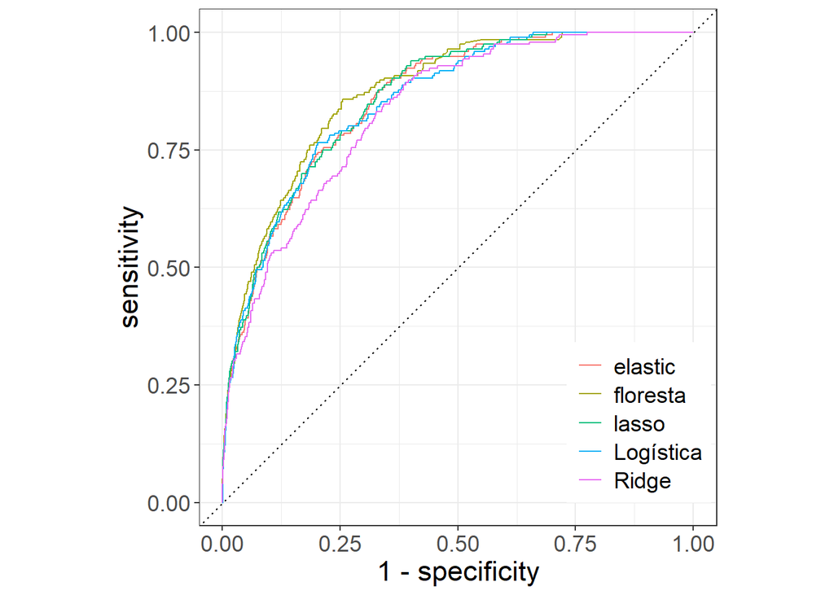

```r
df_avaliacao %>%
  mutate(probabilidade=as.numeric(probabilidade)) %>%
    group_by(modelo) %>%
    roc_curve(deixou_operar, probabilidade,event_level = "second") %>%
    autoplot() +
    labs(color = NULL) +
    theme(legend.position = c(.85, .2),
    text = element_text(size = 17))
```

Visualmente, nada muito diferente, talvez um desempenho inferior da ridge

### AUC

```r
roc_logistica <- roc(teste$Deixou.de.operar, y_logistica)
roc_lasso <-roc(teste$Deixou.de.operar,y_lasso)
roc_ridge <-roc(teste$Deixou.de.operar,y_ridge)
roc_elastic <-roc(teste$Deixou.de.operar,y_elastic_net)
roc_floresta <-roc(teste$Deixou.de.operar,y_floresta)

# Extrair os valores de AUC
auc_logistica <- auc(roc_logistica)
auc_lasso <- auc(roc_lasso)
auc_ridge <- auc(roc_ridge)
auc_elastic <- auc(roc_elastic)
auc_floresta <- auc(roc_floresta)

auc_table <- auc_table %>%
  bind_rows(tibble(
  Modelo = c("logistica","lasso", "ridge", "elastic","floresta"),
  dataset = "oversampling",
  AUC = c(auc_logistica, auc_lasso, auc_ridge,auc_elastic,auc_floresta)
)) %>%
  arrange(desc(AUC))


# Exibir a tabela
print(auc_table)
```

```
## # A tibble: 15 × 3
##    Modelo    dataset        AUC
##    <chr>     <chr>        <dbl>
##  1 floresta  undersamplig 0.888
##  2 floresta  original     0.885
##  3 floresta  oversampling 0.873
##  4 lasso     undersamplig 0.871
##  5 elastic   undersamplig 0.870
##  6 elastic   original     0.863
##  7 lasso     original     0.862
##  8 lasso     oversampling 0.861
##  9 logistica original     0.860
## 10 elastic   oversampling 0.859
## 11 logistica undersamplig 0.856
## 12 logistica oversampling 0.855
## 13 ridge     undersamplig 0.852
## 14 ridge     oversampling 0.834
## 15 ridge     original     0.833
```

O melhor desempenho continua sendo da floresta usando o dados reduzidos para treino.

## F1-Score

```r
f1_score_over <- crossing(modelo = c("logistica","lasso",
                                        "ridge","elastic","floresta"),
                             corte=seq(0, 1, 0.001))

f1_score_over <- f1_score_over %>%
  mutate(dataset="undersamplig",
    f1 = map2_dbl(corte, modelo, ajusta_f1))

# juntando com os resultados do dataset original
f1_score <- bind_rows(f1_score,f1_score_over) %>%
  arrange(desc(f1))

f1_score
```

| modelo | corte | dataset | f1 |
| --- | --- | --- | --- |
| floresta | 0.291 | original | 0.36746988 |
| floresta | 0.306 | original | 0.36593060 |
| floresta | 0.307 | original | 0.36593060 |
| floresta | 0.308 | original | 0.36593060 |
| floresta | 0.309 | original | 0.36593060 |
| floresta | 0.310 | original | 0.36593060 |
| floresta | 0.299 | original | 0.36532508 |
| floresta | 0.300 | original | 0.36532508 |
| floresta | 0.288 | original | 0.36526946 |
| floresta | 0.289 | original | 0.36526946 |

[output cut: 9990 more lines]

A f1 tb não teve alteração

### Melhor modelo

O modelo com o melhor desempenho para o nosso caso é a floresta aleatória.

### Explicabilidade

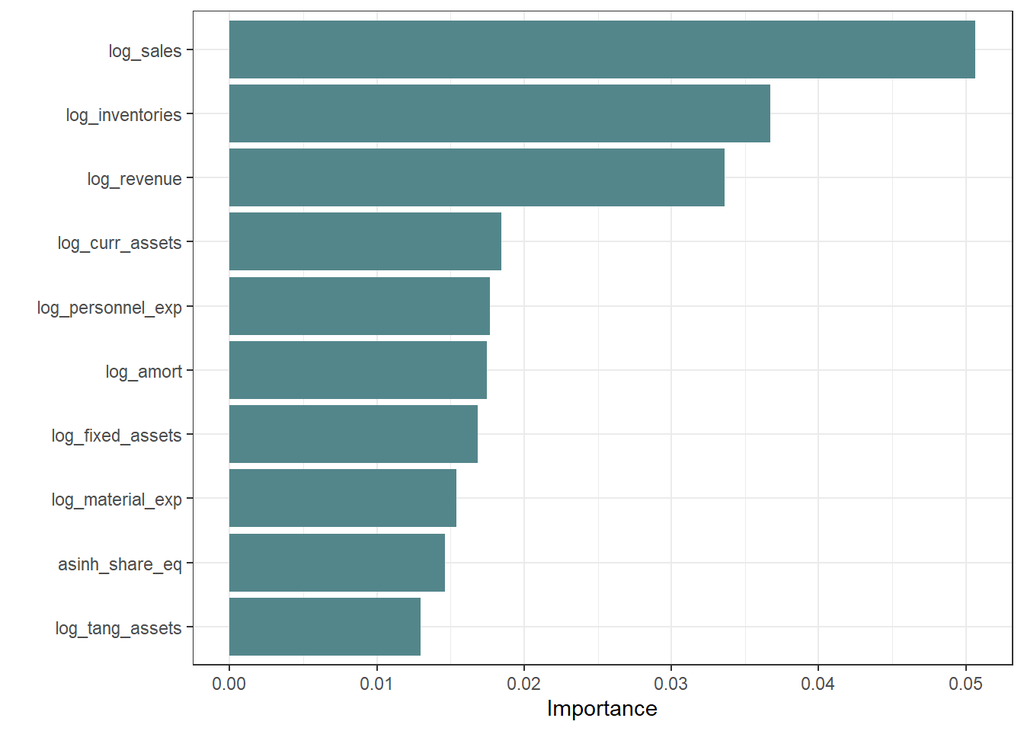

```r
vip(rf_under, aesthetics = list(fill = "#53868B"))+
  theme_bw()
```

A variável mais importante para a floresta é log_sales e também outras relacionadas com as variáveis financeiras.

## Contexto financeiro

Vamos criar a função de lucro e testar para um cenário hipotético

#### Função de lucro

```r
lucro_esperado <- function(predito, observado,
                           lucro_vp, lucro_vn, prejuizo_fp, prejuizo_fn,
                           cortes = seq(0, 1, by = 0.01)) {

  # Criar um vetor para armazenar os lucros para cada ponto de corte
  lucros <- numeric(length(cortes))

  # Loop por cada ponto de corte
  for (i in seq_along(cortes)) {

    # Definir o ponto de corte atual
    corte <- cortes[i]

    # Prever classes com base no ponto de corte
    pred_classes <- ifelse(predito >= corte, 1, 0)

    #quantidade de observações
    n = length(predito)

    # Criar a matriz de confusão
    tp <- sum(pred_classes == 1 & observado == 1)  # Verdadeiros Positivos
    tn <- sum(pred_classes == 0 & observado == 0)  # Verdadeiros Negativos
    fp <- sum(pred_classes == 1 & observado == 0)  # Falsos Positivos
    fn <- sum(pred_classes == 0 & observado == 1)  # Falsos Negativos

    # Calcular o lucro para o ponto de corte atual
    lucro_total <- (tp * lucro_vp) + (tn * lucro_vn) + (fp * prejuizo_fp) + (fn * prejuizo_fn)

    lucro_esperado = lucro_total/n

    # Armazenar o lucro calculado
    lucros[i] <- lucro_esperado
  }

  # Retornar uma tibble com os pontos de corte e seus respectivos lucros
  return(tibble(corte = cortes, lucro = lucros))
}
```

## Cenário de exemplo

Vamos exemplificar o uso dessa função de lucro em um cenário de investimentos, onde um agente tomaria a decisão de comprar ou não acões de uma empresa, baseando-se nas previsões do modelo.

### Acões e resultados

- Verdadeiro positivo: O investidor não compra papéis da empresa e ela deixa de operar
- Verdadeiro negativo: O investidor compra e empresa não deixa de operar, recebendo assim um retorno de 25%
- Falso positivo: O investidor não investe e a empresa não deixa de operar, logo ele não realiza um lucro de 25% caso tivesse investido
- Falso negativo: O modelo diz que a empresa vai continuar operando, mas ela deixa, e o investidor perde 100% do capital investido

### Definindo lucros e prejuízos

```r
lucro_vp <- 0 # Lucro para verdadeiro positivo
lucro_vn <- 0.25  # Lucro para verdadeiro negativo
prejuizo_fp <- -0.25  # prejuizo para falso positivo
prejuizo_fn <- -1  # prejuizo para falso negativo
```

calculando o valor esperado para esse cenário

```r
resultado <- tibble(lucro_esperado(y_logistica,teste$Deixou.de.operar,
                           lucro_vp,lucro_vn,prejuizo_fp,prejuizo_fn),
                    modelo = "Logística") %>%
  bind_rows(tibble(lucro_esperado(y_lasso,teste$Deixou.de.operar,
                           lucro_vp,lucro_vn,prejuizo_fp,prejuizo_fn),
                    modelo = "lasso")) %>%
  bind_rows(tibble(lucro_esperado(y_ridge,teste$Deixou.de.operar,
                           lucro_vp,lucro_vn,prejuizo_fp,prejuizo_fn),
                    modelo = "Ridge")) %>%
   bind_rows(tibble(lucro_esperado(y_elastic_net,teste$Deixou.de.operar,
                           lucro_vp,lucro_vn,prejuizo_fp,prejuizo_fn),
                    modelo = "elastic")) %>%
  bind_rows(tibble(lucro_esperado(y_floresta,teste$Deixou.de.operar,
                           lucro_vp,lucro_vn,prejuizo_fp,prejuizo_fn),
                   modelo = "floresta"))
resultado %>%  arrange(desc(lucro))
```

| corte | lucro | modelo |
| --- | --- | --- |
| 0.24 | 0.20827985 | elastic |
| 0.56 | 0.20827985 | floresta |
| 0.57 | 0.20827985 | floresta |
| 0.21 | 0.20818815 | elastic |
| 0.53 | 0.20818815 | floresta |
| 0.54 | 0.20818815 | floresta |
| 0.24 | 0.20809646 | lasso |
| 0.44 | 0.20809646 | floresta |
| 0.55 | 0.20809646 | floresta |
| 0.25 | 0.20800477 | lasso |

[output cut: 495 more lines]

Para esse cenário, os modelos elastic net e a floresta aleatória proporcionam resultados idênticos, trazendo um retorno de aproximadamente 21%